# Lab 1A

## Geoms

The geoms determine how the data are represented in the plot. There are many different geoms, including those for displaying histograms, lines, points, densities, bars, boxplots, etc.

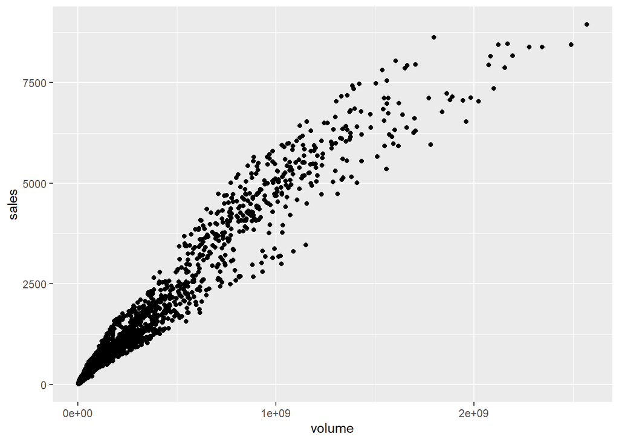

```r
ggplot(data = na.omit(txhousing), mapping = aes(x = volume, y = sales)) +
  geom_point()
```

2. Add a (non-linear) regression line to the previous plot that describes the relationship between `volume` and `sales`.

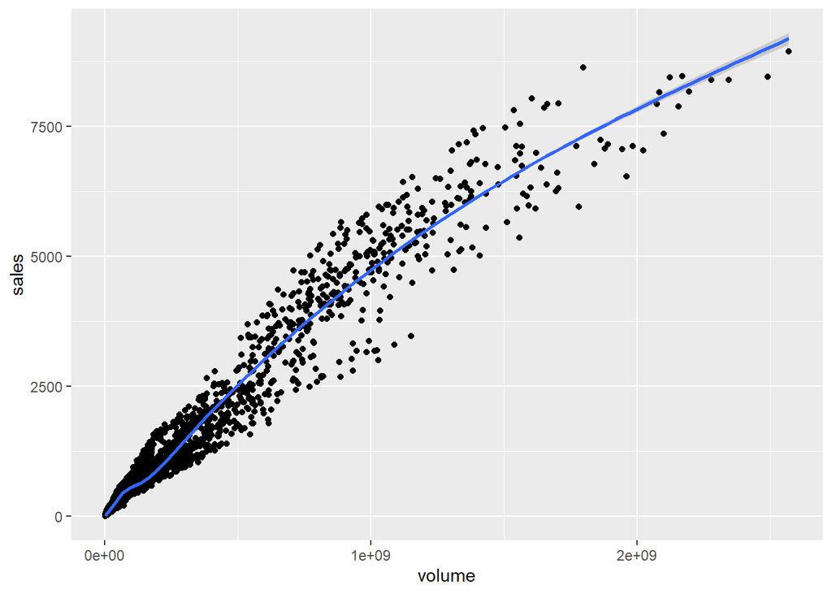

```r
ggplot(data = na.omit(txhousing), mapping = aes(x = volume, y = sales)) +
  geom_point() +
  geom_smooth()
```

3. The data are collected over the period 2000-2015. Use a 3rd aesthetic `color` to color the points in the scatter plot by year.

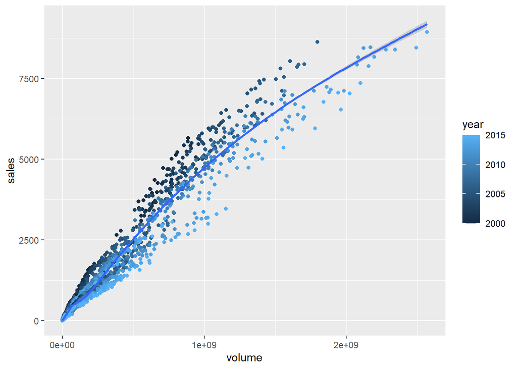

```r
ggplot(data = na.omit(txhousing), mapping = aes(x = volume, y = sales, col = year)) +
  geom_point() +
  geom_smooth()
```

## Scales, facets, themes

The scale on which the axis are represent can be changed by adding a `scale` layer to the plot. For example, `scale_y_sqrt()` transforms the y-axis to the square root of the original values, and `scale_y_log10()` takes the logarithm of the original values. Thes kind of transformations can be useful to reduce heteroscedasticity (non-constant variance around the regression line).

1. Display the previous plot choosing the transformation that does the best job in reducing heteroscedasticity.

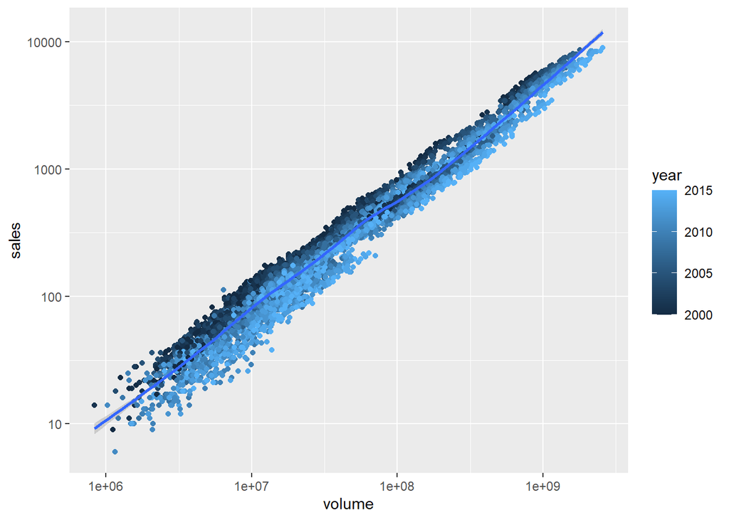

```r
ggplot(data = na.omit(txhousing), mapping = aes(x = volume, y = sales, col = year)) +
  geom_point() +
  geom_smooth() +
  scale_y_log10() +
  scale_x_log10()
```

Facets are multiples of the plot, split up by the levels of categorical variable.

2. Remove the variable `year` from the aesthetics, and use the `facet_wrap()` or `facet_grid()` function to make multiples by `year`.

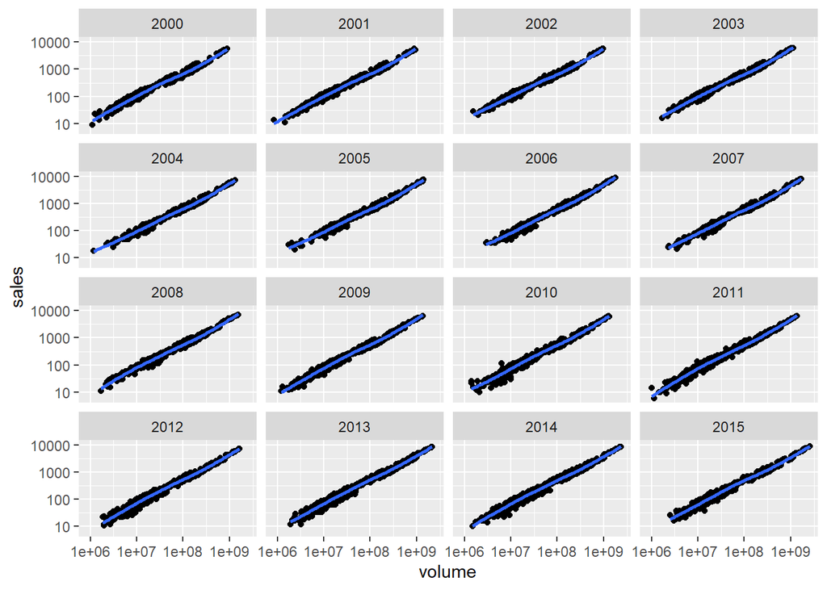

```r
ggplot(data = na.omit(txhousing), mapping = aes(x = volume, y = sales)) +
  geom_point() +
  geom_smooth() +
  scale_y_log10() +
  scale_x_log10() +
  facet_wrap(vars(year))
```

Themes are uses to change the look of the plot.

3. Check the theme options in the cheat sheet, and choose a theme of your liking to display the previous plot.

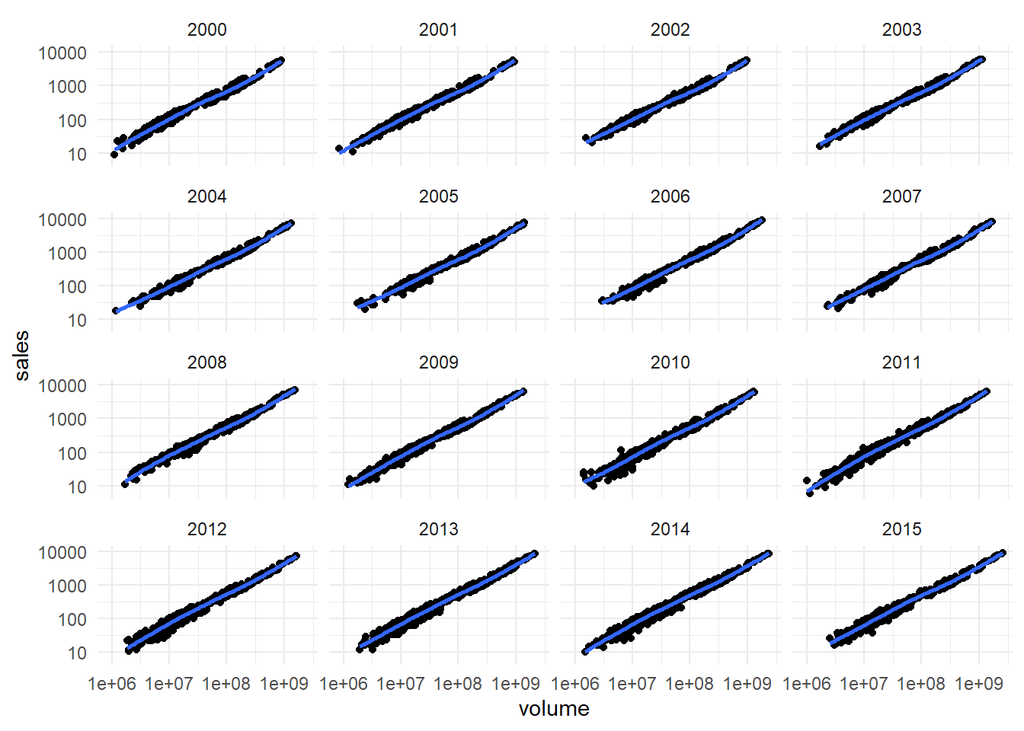

```r
ggplot(data = na.omit(txhousing), mapping = aes(x = volume, y = sales)) +
  geom_point() +
  geom_smooth() +
  scale_y_log10() +
  scale_x_log10() +
  facet_wrap(vars(year)) +
  theme_minimal()
```

# Other geoms

In the previous exercise we used geoms for two numeric variables to display a scatter plot with a regression line. We will now briefly explore some geoms for categorical variables, and for combinations of numeric and categorical variables.

1. Display a histogram of the variable `sales`, with the x-axis displayed on a logarithmic scale.

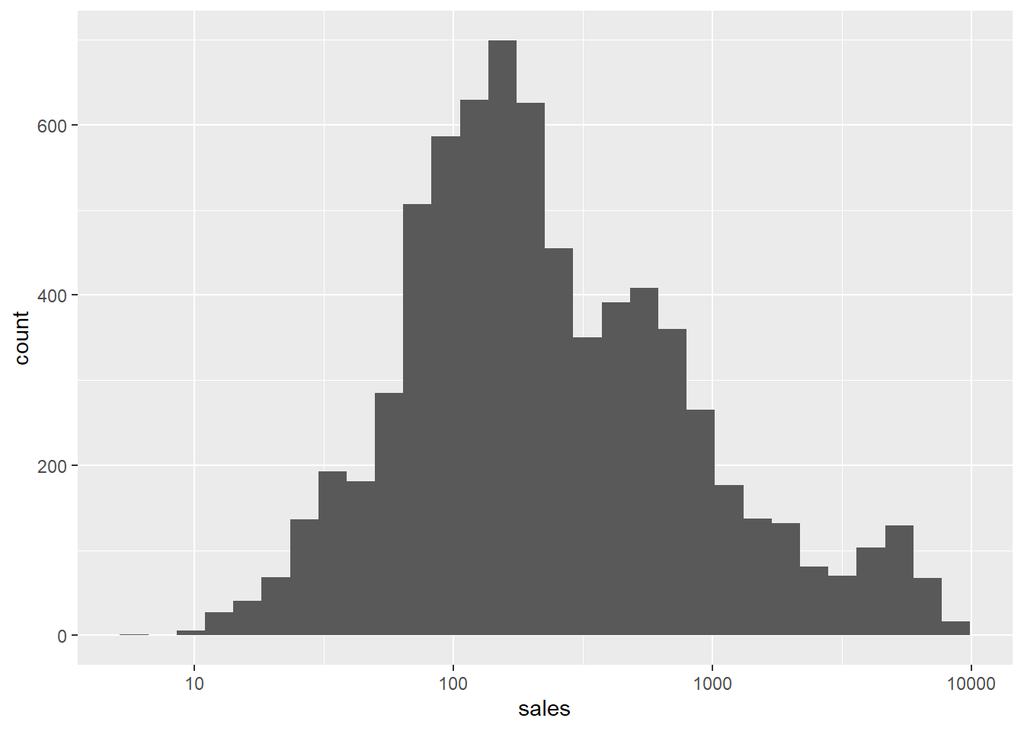

```r
ggplot(data = na.omit(txhousing), mapping = aes(x = sales)) +
  geom_histogram() +
  scale_x_log10()
```

2. Add the aesthetic `fill = factor(month)` to the plot

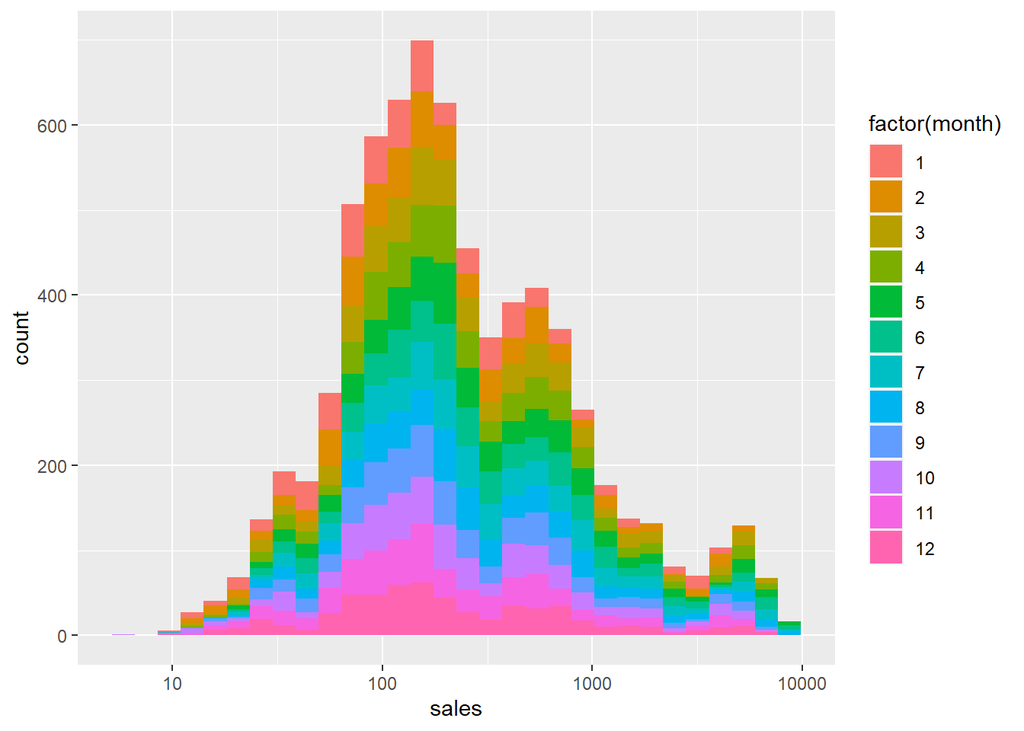

```r
ggplot(data = na.omit(txhousing), mapping = aes(x = sales, fill = factor(month))) +
  geom_histogram() +
  scale_x_log10()
```

3. The previous plot is a bit crowded with colors. A better option is to produce separate histograms for each month. Disply this plot.

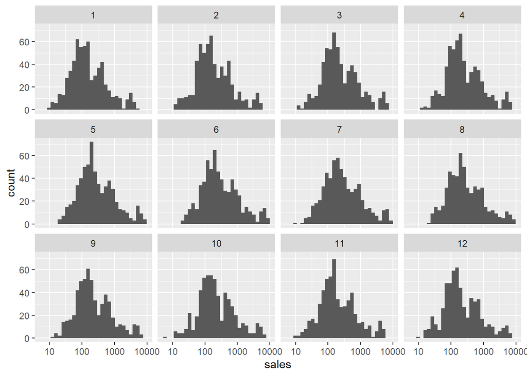

```r
ggplot(data = na.omit(txhousing), mapping = aes(x = sales)) +
  geom_histogram() +
  scale_x_log10() +
  facet_wrap(vars(month))
```

4. Change the geom of the previous plot so that densities instead of histograms are displayed.

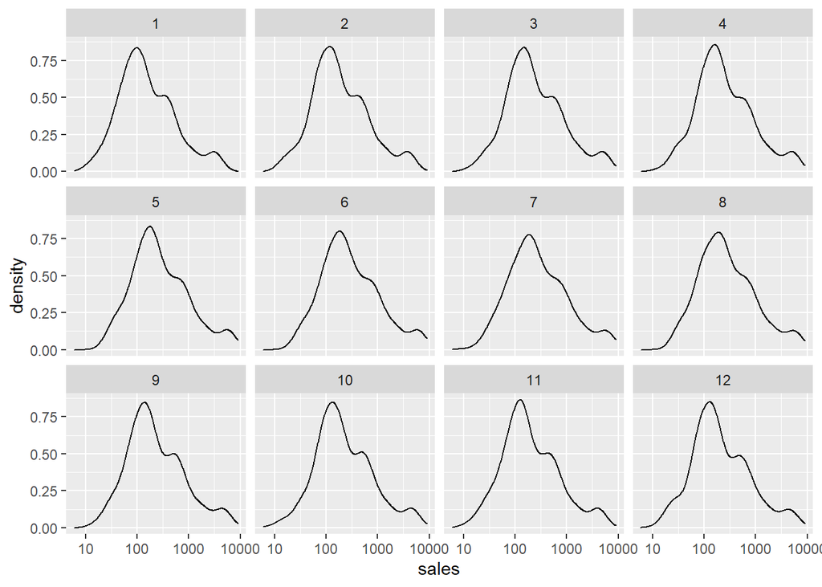

```r
ggplot(data = na.omit(txhousing), mapping = aes(x = sales)) +
  geom_density() +
  scale_x_log10() +
  facet_wrap(vars(month))
```

4. Display the same graph as in exercise b, but with a geom that creates boxplots for each month (specify `month` as `factor`).

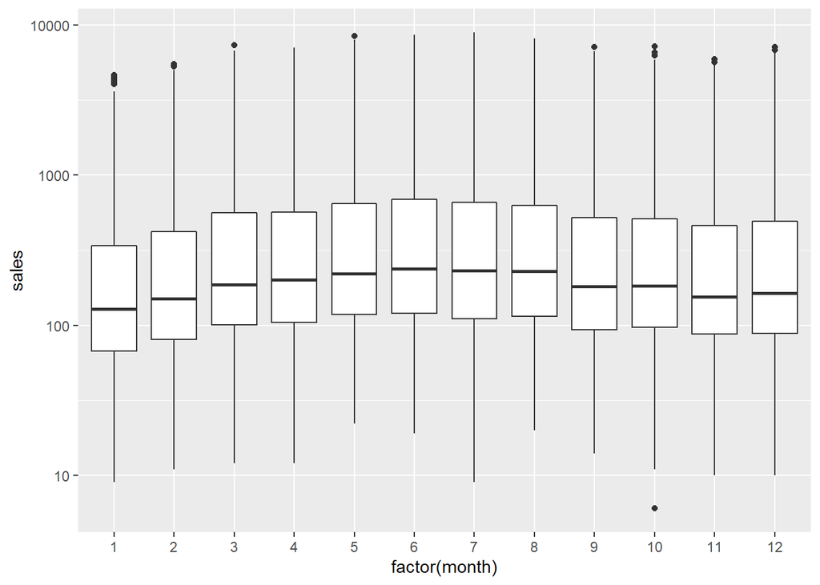

```r
ggplot(data = na.omit(txhousing), mapping = aes(x = factor(month), y = sales)) +
  geom_boxplot() +
  scale_y_log10()
```

END OF LAB.